# Final

Melissa Chi

12/06/2020

# Data Glimpse

|  | id | categories | latitude | longitude | name | postalCode | province | county_name | state_name | TotalPop | Men | Women | Hispanic | White | Black | Native | Asian | Pacific | Income | Poverty | Professional | Service | Office | Construction | Production | Drive | Transit | Walk | WorkAtHome | … |
| --- | --- | --- | --- | --- | --- | --- | --- | --- | --- | --- | --- | --- | --- | --- | --- | --- | --- | --- | --- | --- | --- | --- | --- | --- | --- | --- | --- | --- | --- | --- |
| 1 | AWrSh_KgsVYjT2BJAzaH |  | 40.39629 | -104.6970 | carls jr | 80631 | CO | Weld | Colorado | 285729 | 143783 | 141946 | 29.0 | 66.4 | 1.0 | 0.4 | 1.3 | 0.1 | 66489 | 11.2 | 33.2 | 16.9 | 22.7 | 13.0 | 14.2 | 80.0 | 0.6 | 2.1 | 5.5 | … |
| 2 | AWEKlA-LIxWefVJwxG9B |  | 39.08135 | -108.5869 | del taco | 81505 | CO | Mesa | Colorado | 148798 | 73478 | 75320 | 14.2 | 81.8 | 0.7 | 0.6 | 0.7 | 0.1 | 51971 | 16.0 | 33.8 | 18.4 | 23.7 | 12.5 | 11.6 | 77.9 | 0.4 | 3.7 | 6.2 | … |
| 3 | AWrSfAcYsVYjT2BJAzPt |  | 39.09148 | -108.5541 | which wich | 81506 | CO | Mesa | Colorado | 148798 | 73478 | 75320 | 14.2 | 81.8 | 0.7 | 0.6 | 0.7 | 0.1 | 51971 | 16.0 | 33.8 | 18.4 | 23.7 | 12.5 | 11.6 | 77.9 | 0.4 | 3.7 | 6.2 | … |
| 4 | AWrSa3NAQTFama1Xpkbz |  | 39.76369 | -104.7767 | chipotle mexican grill | 80011 | CO | Adams | Colorado | 487850 | 245840 | 242010 | 39.3 | 51.1 | 3.0 | 0.5 | 3.8 | 0.1 | 64087 | 12.2 | 29.8 | 18.9 | 24.1 | 13.7 | 13.5 | 77.7 | 3.8 | 1.2 | 5.0 | … |
| 5 | AWrSaVGzZ4Yw-wtdgcaB |  | 39.74044 | -104.9264 | taco bell | 80220 | CO | Denver | Colorado | 678467 | 339400 | 339067 | 30.5 | 53.6 | 9.2 | 0.5 | 3.5 | 0.1 | 60098 | 15.1 | 46.1 | 16.8 | 21.5 | 7.9 | 7.7 | 69.9 | 6.8 | 4.4 | 7.6 | … |
| 6 | AWrSaQ5RZ4Yw-wtdgcZw |  | 39.73967 | -105.0047 | mcdonalds | 80204 | CO | Denver | Colorado | 678467 | 339400 | 339067 | 30.5 | 53.6 | 9.2 | 0.5 | 3.5 | 0.1 | 60098 | 15.1 | 46.1 | 16.8 | 21.5 | 7.9 | 7.7 | 69.9 | 6.8 | 4.4 | 7.6 | … |

# Introduction

Fast food restaurants are plentiful in the United States. With many options to choose from, I’m interested in exploring the potential relationships between fast food restaurants and demographics across the USA. I will be working with a dataset combining data on fast food restaurants and census demographic data. More in depth explanation and credit can be found in the codebook.

Let’s begin!

# Where are Fast Food Restaurants Located in the USA?

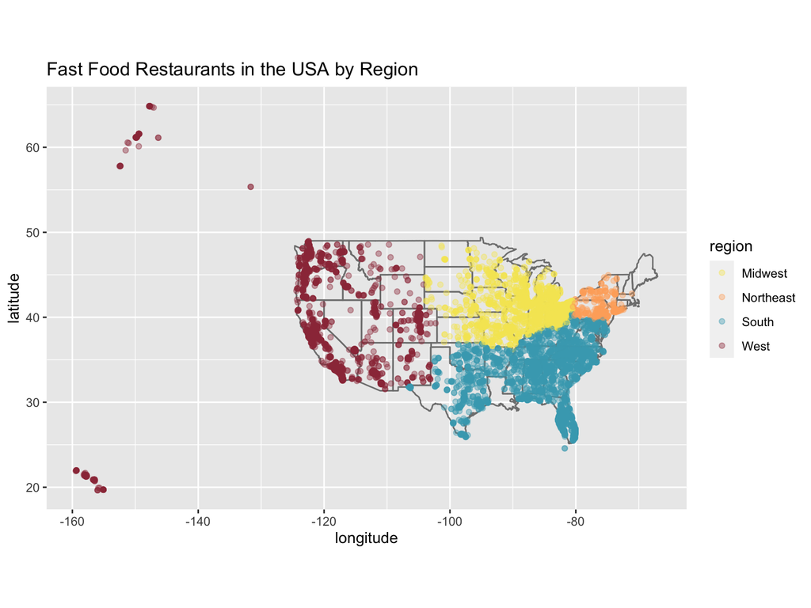

| region | restaurant_count | percentage_of_total |
| --- | --- | --- |
| South | 4205 | 44.036025 |
| Midwest | 2679 | 28.055294 |
| West | 2307 | 24.159598 |
| Northeast | 358 | 3.749084 |

**Insight: Based only on the number of fast food restaurants located in the region, the South contains the most fast food restaurants.**  
This form a measuring can bring in some uncertainties though. We are measuring purely based on the number of restaurants found in a certain region, however, some regions of the USA are geographically smaller than others (ex: compare the Northeast to the South). We could try to measure fast food restaurants per area, but that would require other datasets to be combined. However, we can try to examine the number of fast food restaurants per capita as another measure of fast food restaurants that is less geographically oriented and considers the population. Let’s look at number of fast food restaurants per capita to see if this gives us similar results.

| region | restaurant_per_capita |
| --- | --- |
| Midwest | 4.472887e-05 |
| South | 4.134045e-05 |
| West | 3.147912e-05 |
| Northeast | 1.416159e-05 |

Looking at the rankings, our calculations were similar with one difference. The Midwest actually has the highest Restaurant per Capita, followed closely by the South, then the West, and the Northeast.

**Insight: The region with the most fast food restaurants per Capita is the Midwest.** Perhaps this means that the Midwest may have the most fast food restaurants per area, but that will have to be explored another time.

# What are the Most Popular Fast Food Restaurants in the USA?

Now that we know where fast food restaurants are located, let’s look into the popularity of different brands of fast food restaurants.

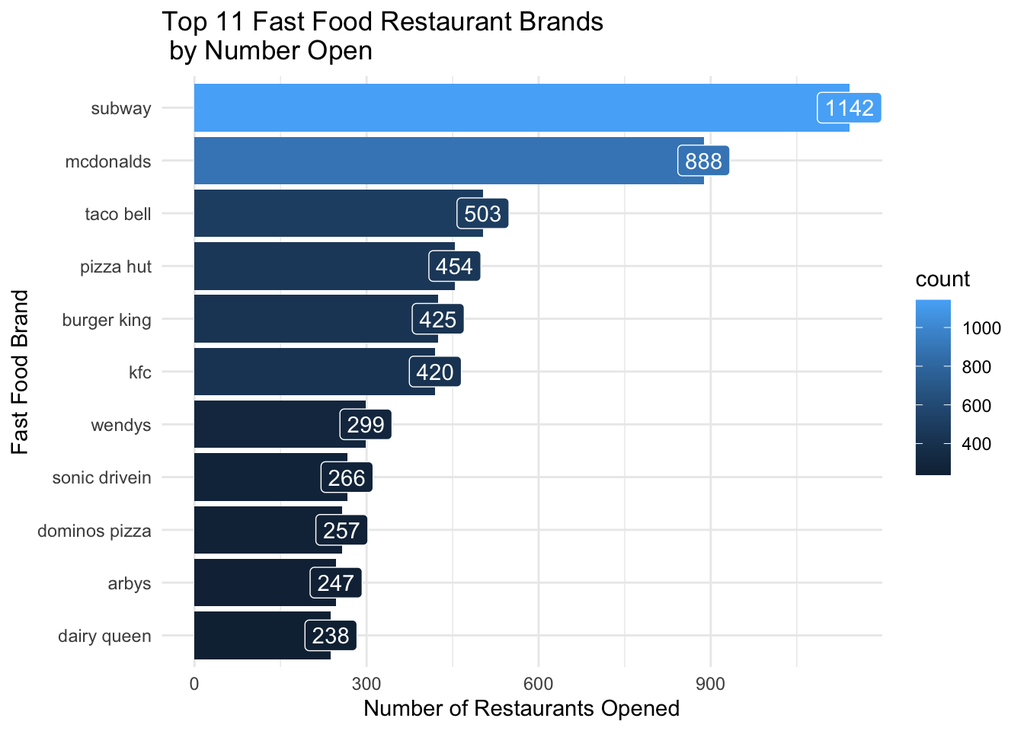

Based on the number of restaurants opened, the most popular fast food restaurant nationally is Subway followed by McDonald’s and Taco Bell. Let’s see if this result is echoed across the individual regions.

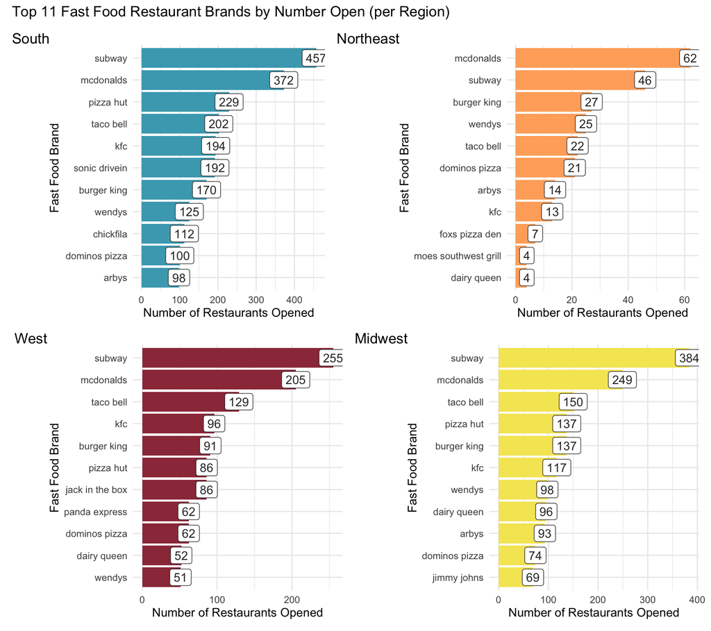

The top restaurants across each region generally echo the national trend, with Subway, McDonald’s, and Taco Bell remaining in the top 5. However, we begin to see some regional preferences appear. For example, ‘Panda Express’ appears as a top contender in the West but no where else.

**Insight: Each region in the USA generally has the same top fast food restaurants, however, there are restaurants that are more popular in different region.**

Perhaps if you’re planning on opening a fast food franchise, it would be strategic to open somewhere where the restaurant already has a following. On the flip side, if you’re a restaurant owner who loves to be daring, then opening up a new franchise in a sea of familiar ones will seem new and novel, drawing in a different crowd.

# Do Regions have a Preference on the Type Fast Food Restaurants?

We were able to see how each region have different popular fast food brands. Let’s explore this insight further and see if regions have differing fast food category preferences. The table below shows the 6 most common fast food categories that appear in each region.

```
##
##
## Table: West
##
## Category         Freq
## --------------  -----
## american         1067
## sandwich          757
## hamburgers        604
## mexican           517
## hot dogs          417
## delicatessens     409
##
##
## Table: South
##
## Category         Freq
## --------------  -----
## american         2399
## sandwich         1544
## hamburgers       1198
## hot dogs          863
## delicatessens     783
## chicken           708
##
##
## Table: Northeast
##
## Category      Freq
## -----------  -----
## sandwich       133
## hamburgers     105
## american        78
## hot dogs        60
## breakfast       59
## burger          58
##
##
## Table: Midwest
##
## Category         Freq
## --------------  -----
## sandwich         1174
## american         1116
## hamburgers        698
## delicatessens     622
## hot dogs          490
## ice cream         452
```

| Region | Unique Category |
| --- | --- |
| West | Mexican |
| Midwest | Ice Cream |
| South | Chicken |
| Northeast | Breakfast |

We see that the West has a preferences for Mexican food. The South loves chicken. The Northeast loves breakfast food and the Midwest are big ice cream fans.

**Insight: Regions do in fact have preferences for certain categories of fast food restaurants that are specific only to that region.**

For someone who may interested in opening up a fast food franchise, consider the preferences of your audiences before opening! For example, a Korean fried chicken place could do well in the South, as we saw that the South has many chicken fast food restaurants, however it may not do great in the Northeast.

Each region may have a different preferences that lead to different popular restaurant brands. However, it could another reason - perhaps fast food restaurants appear based not on preferences, but certain demographics. Let’s explore that.

# Do Fast Food Restaurants Target Certain Demographics?

Fast food restaurants are for everyone, however, they may target certain demographics. In the USA, are fast food locations intentional?

| Var1 | Freq |
| --- | --- |
| count | 1.00 |
| Walk | -0.34 |
| Production | 0.32 |
| Income | -0.31 |
| Professional | -0.31 |
| Unemployment | 0.31 |
| Poverty | 0.26 |
| Drive | 0.24 |
| Native | -0.21 |
| Office | 0.20 |

[output cut: 13 more lines]

Looking at the whole USA, there are no strong correlations between the number of fast food restaurants and the state they appear in. The most significant correlation comes from Walk, Production, Income, Professional, and Unemployment. Only Unemployment and Production have positive correlation.

Let’s check the correlation between number of fast food restaurants and demographics by region.

| Var1 | Freq |
| --- | --- |
| count | 1.00 |
| Professional | -0.97 |
| Income | -0.96 |
| Transit | -0.92 |
| Walk | -0.90 |
| Poverty | 0.86 |
| Employed | -0.77 |
| Women | -0.74 |
| TotalPop | -0.72 |
| Men | -0.71 |

[output cut: 13 more lines]

Looking at correlations of fast food restaurants and demographic by region show some more interesting and stronger correlations. There seems to be strong negative correlations with Professional, Income, Transit, and Walk, and a strong positive correlation with Poverty.

The difference in correlation strength could be due to the division of each region. Each region is demographically different from each other and these effects could be confounded when looking at the correlations by state. Let’s explore these variables by region.

```
##        region       Men             Women            Income
##  Midwest  :1   Min.   : 58592   Min.   : 60482   Min.   :47425
##  Northeast:1   1st Qu.: 66559   1st Qu.: 69311   1st Qu.:51669
##  South    :1   Median :106269   Median :110295   Median :54233
##  West     :1   Mean   :104576   Mean   :107924   Mean   :53532
##                3rd Qu.:144287   3rd Qu.:148908   3rd Qu.:56096
##                Max.   :147176   Max.   :150626   Max.   :58237
##     TotalPop         Hispanic          White           Black
##  Min.   :119074   Min.   : 5.151   Min.   :67.67   Min.   : 1.693
##  1st Qu.:135870   1st Qu.: 6.152   1st Qu.:69.01   1st Qu.: 3.190
##  Median :217709   Median : 8.038   Median :76.46   Median : 4.593
##  Mean   :212501   Mean   :10.452   Mean   :76.92   Mean   : 6.829
##  3rd Qu.:294340   3rd Qu.:12.338   3rd Qu.:84.37   3rd Qu.: 8.232
##  Max.   :295511   Max.   :20.583   Max.   :87.10   Max.   :16.436
##      Native           Asian          Pacific           Poverty
##  Min.   :0.1988   Min.   :1.355   Min.   :0.01163   Min.   :13.00
##  1st Qu.:0.5634   1st Qu.:1.374   1st Qu.:0.03839   1st Qu.:13.50
##  Median :0.8422   Median :1.925   Median :0.04932   Median :14.50
##  Mean   :1.2583   Mean   :2.182   Mean   :0.12333   Mean   :15.00
##  3rd Qu.:1.5372   3rd Qu.:2.734   3rd Qu.:0.13426   3rd Qu.:16.01
##  Max.   :3.1500   Max.   :3.523   Max.   :0.38306   Max.   :18.02
##   Professional      Service          Office       Construction
##  Min.   :31.27   Min.   :17.44   Min.   :22.15   Min.   : 9.171
##  1st Qu.:31.82   1st Qu.:17.93   1st Qu.:22.34   1st Qu.:10.078
##  Median :32.70   Median :18.18   Median :22.66   Median :10.964
##  Mean   :33.14   Mean   :18.38   Mean   :22.63   Mean   :10.973
##  3rd Qu.:34.02   3rd Qu.:18.62   3rd Qu.:22.95   3rd Qu.:11.860
##  Max.   :35.87   Max.   :19.72   Max.   :23.04   Max.   :12.794
##    Production       Transit         WorkAtHome       Employed
##  Min.   :11.68   Min.   :0.6908   Min.   :3.637   Min.   : 57921
##  1st Qu.:13.24   1st Qu.:0.7296   1st Qu.:4.077   1st Qu.: 63337
##  Median :14.91   Median :1.2924   Median :4.281   Median :101345
##  Mean   :14.88   Mean   :1.6352   Mean   :4.497   Mean   :100965
##  3rd Qu.:16.55   3rd Qu.:2.1980   3rd Qu.:4.702   3rd Qu.:138973
##  Max.   :18.03   Max.   :3.2651   Max.   :5.790   Max.   :143249
##      Drive            Walk        Unemployment       count
##  Min.   :75.30   Min.   :1.751   Min.   :5.356   Min.   : 358
##  1st Qu.:77.67   1st Qu.:2.514   1st Qu.:5.891   1st Qu.:1820
##  Median :80.10   Median :3.314   Median :6.465   Median :2493
##  Mean   :79.51   Mean   :3.112   Mean   :6.385   Mean   :2387
##  3rd Qu.:81.94   3rd Qu.:3.912   3rd Qu.:6.958   3rd Qu.:3060
##  Max.   :82.57   Max.   :4.067   Max.   :7.253   Max.   :4205
```

Across the regions, we can see major discrepancies with the minimums and maximums. This confirms out conclusion of segmenting the USA first to see the targeting of fast food restaurants.

Let’s paint a picture of the target demographic that fast food restaurants are looking at. Looking at the description of the variables from the codebook, fast food restaurants are more prominent places where people do not work in the professional sector, which is defined by employment in management, business, science, and arts. People have lower median household income and they are not walking to work or commuting by public transportation. They seem to be targeting people that are under the poverty level. Fast food restaurants are typically inexpensive, making it seem reasonable that they are located in places where people have lower income. They are also aiming towards people who do not walk to work or commute via public transportation to work, meaning that they mostly drive, bike, or have some other form of transportation. This also makes sense as fast food restaurants are called “fast food” for their ability to produce food quickly and conveniently. Thus, many of them have drive-thru’s, where customers are able to stay in their car and get their food. Ultimately, the high correlations do signify a target demographic across the regions.

**Insight: Fast food restaurants target lower income individuals and individuals that drive to work.**

# Conclusion

Through this EDA, we were able to explore the relationships between fast food restaurants and USA regional demographics. The insights derived may be interesting for the everyday consumer, however, they are useful for marketers and business owners.

For marketers, the demographics insights seen can lead to more regional advertising. For example, a marketer can see other popular fast food competitors regionally, creating a campaign to distinguish themselves from regionally popular fast food brands.

For the business owners, the analysis on the regional preferences is valuable market research. For example, if you’re looking to open a certain type of fast food restaurant, this analysis provides insight into which region may be more favorable. Similarly, entrepreneurs may find these insights useful, as they can see where their competition is lacking and open an exciting new fast food place that makes them stand out.

In the future, I would love to explore more demographic data along with the fast food data, such as looking at consumer purchasing behaviors, attitudes, and other psychographics to do more in depth market research.